# README

### `MissingBVS`: Bayesian Variable Selection with missing data using R

`MissingBVS` is an R package currently on development. It is designed to be highly intuitive, similar to the well-known lm and glm functions, in order to appeal a wide range of users from different disciplines. The package provides several functions to deal with the dual problem of model uncertainty and the presence of missing data by the proper Bayes factor and posterior distribution computation.

## Methodology

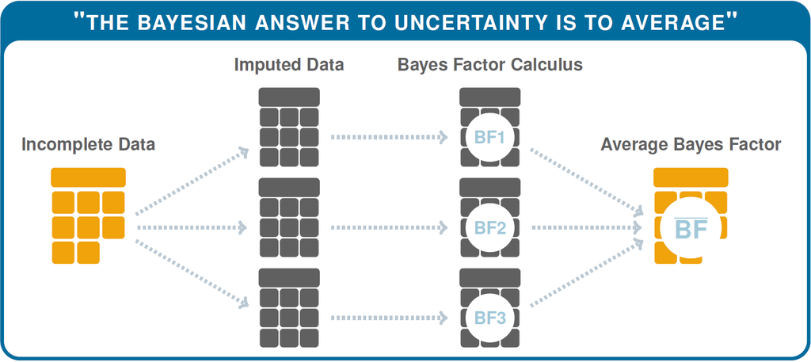

https://github.com/camulro/MissingBVS

`MissingBVS` deals with the Bayesian Variable Selection problem in the presence of missing data by performing a multiple imputation proccess and computing the Bayes factor for each model as an average of the diferent Bayes factores over the bunch of imputed datasets. It can be applied to both linear and generalized linear models, in order to cover a broad range of real problems.

The advanced user has the possibility of using several popular priors from the well-stablished literature and approximations of the Bayes factor as well. The process can be done through exact algorithms to perform fast computations in problems of small to moderate size and heuristic sampling methods to solve the larger ones.

## Installing steps

To install the latest development version, you can use `install_github` from the `devtools` package:

```r
## install devtools if necessary for install_github()
install.packages('devtools')
library(devtools)
## get the package from github
install_github('camulro/MissingBVS', dependencies = TRUE)
```

## References

- Barbieri, M and Berger, J. (2004). Optimal Predictive Model Selection. *The Annals of Statistics, 32*: 870-897. DOI: 10.1214/009053604000000238
- Bayarri, M.J., Berger, J.O., Forte, A. and Garcia-Donato, G. (2012). Criteria for Bayesian Model choice with Application to Variable Selection. *Annals of Statistics, 40*: 1550-1577. DOI: 10.1214/12-aos1013
- van Buuren, S. and Groothuis-Oudshoorn, K. (2011). mice: Multivariate Imputation by Chained Equations in R. *Journal of Statistical Software, 45*(3): 1–67. DOI: 10.18637/jss.v045.i03
- Clyde, M (2025) BAS: Bayesian Variable Selection and Model Averaging using Bayesian Adaptive Sampling. *R package version 2.0.2* https://CRAN.R-project.org/package=BAS.
- Fernandez, C., Ley, E. and Steel, M.F.J. (2001). Benchmark priors for Bayesian model averaging. *Journal of Econometrics, 100*: 381-427. DOI: 10.1016/s0304-4076(00)00076-2
- García-Donato, G., Castellanos, M.E., Cabras, S., Quirós, A. and Forte, A. (2025). Model Uncertainty and Missing Data: An Objective Bayesian Perspective (with Discussion). *Bayesian Analysis, 20*: 1677–1778. DOI: [10.1214/25-ba1531](https://doi.org/10.1214/25-BA1531)
- Garcia-Donato, G. and Forte, A. (2018). Bayesian Testing, Variable Selection and Model Averaging in Linear Models using R with BayesVarSel. *The R Journal, 10*(1): 155–174. Retrieved from https://journal.r-project.org/archive/2018/RJ-2018-021/index.html
- Garcia-Donato, G. and Martinez-Beneito, M.A.(2013). On sampling strategies in Bayesian variable selection problems with large model spaces. *Journal of the American Statistical Association, 108*: 340-352. DOI: 10.1080/01621459.2012.742443
- Held, L., Sabanés Bové, D. and Gravestock, I. (2015). Approximate Bayesian Model Selection with the Deviance Statistic. *Statistical Science, 30*(2): 242-257. DOI: [10.1214/14-sts510](https://doi.org/10.1214/14-STS510)
- Li, Y. and Clyde, M. (2018). Mixtures of g-priors in Generalized Linear Models. *Journal of the American Statistical Association, 113*: 1828-1845. DOI: 10.1080/01621459.2018.1469992
- Liang, F., Paulo, R., Molina, G., Clyde, M. and Berger, J.O. (2008). Mixtures of g-priors for Bayesian Variable Selection. *Journal of the American Statistical Association, 103*: 410-423. DOI: 10.1198/016214507000001337
- Schwarz, G. (1978). Estimating the dimension of a model. *The Annals of Statistics, 6*(2): 461–464. DOI: 10.1214/aos/1176344136
- Scott, J.G. and Berger, J.O. (2010). Bayes and empirical-Bayes multiplicity adjustment in the variable-selection problem. *The Annals of Statistics, 38*: 2587–2619. DOI: 10.1214/10-AOS792
- Zellner, A. and Siow, A. (1980). Posterior Odds Ratio for Selected Regression Hypotheses. *Trabajos de Estadística y de Investigación Operativa, 31*: 585. DOI: 10.1007/bf02888369
- Zellner, A. and Siow, A. (1984). *Basic Issues in Econometrics*. Chicago: University of Chicago.
- Zellner, A. (1986). On Assessing Prior Distributions and Bayesian Regression Analysis with g-prior Distributions. In A. Zellner (ed.), *Bayesian Inference and Decision techniques: Essays in Honor of Bruno de Finetti*, 389-399. Edward Elgar Publishing Limited. DOI: 10.2307/2233941

Grant PID2022-138201NB-100 funded by MICIU/AEI/10.13039/501100011033 and by ERDF/EU.

[figure not shown]